# STAT167 HW1 - Spring 2021

Deisy Diaz

ddiaz022@ucr.edu

## **Homework #1 instructions**

**Review 2021/4/1, 2021/4/6, and 2021/4/8 lecture notes before answering the homework questions**.

This homework contains 2 questions, each with multiple parts, 100 points in total.

Replace **INSERT_YOUR_ANSWER** with your own answers.

- First open this `rmd` file in RStudio and click `Knit -> Knit to HTML` to render it to HTML format.
- It is best to read this `rmd` file and the rendered `html` file side-by-side, while you are working on this homework.
- If the question asks you to write some R code, remember to put your code into a **R code chunk**. Make sure both your R code chunk and its output are visible in the rendered `html` file.
- For this homework, use **R Base Graphics** to generate the figures. Do **NOT** use `ggplot2` for this homework.
- **Please comment your R code thoroughly, and follow the R coding style guideline (https://google.github.io/styleguide/Rguide.xml). Partial credit will be deducted for insufficient commenting or poor coding styles.**
- If you have any question about this homework assignment, we encourage you to post it on [**Piazza**](http://piazza.com/ucr/spring2021/stat167/home).

## **Acknowledgments**

Please list all the help you have received for completing this homework.

**Load necessary packages**

```r
library(datasets) # for the `quakes` data set

## You need to install the maps package first, then you can comment out the following line.
# install.packages("maps")

library(maps) # for map visualization
## Warning: package 'maps' was built under R version 4.0.4
```

## **Question 1 [70pt] Analysis of the `quakes` data set**

The `quakes` data set give the locations of 1000 seismic events of MB > 4.0. The events occurred in a cube near Fiji since 1964.

```r
library(datasets) # we have already loaded the package but we can do it again
?quakes
```

```
## starting httpd help server ... done
```

```r
class(quakes)
## [1] "data.frame"
head(quakes, n=5) # print first 5 rows of quakes
##      lat   long depth mag stations
## 1 -20.42 181.62   562 4.8       41
## 2 -20.62 181.03   650 4.2       15
## 3 -26.00 184.10    42 5.4       43
## 4 -17.97 181.66   626 4.1       19
## 5 -20.42 181.96   649 4.0       11
dim(quakes)  # dimension of the table
## [1] 1000    5
names(quakes)  # list the variables in quakes
## [1] "lat"      "long"     "depth"    "mag"      "stations"
str(quakes)  # list the structures in quakes
## 'data.frame':    1000 obs. of  5 variables:
##  $ lat     : num  -20.4 -20.6 -26 -18 -20.4 ...
##  $ long    : num  182 181 184 182 182 ...
##  $ depth   : int  562 650 42 626 649 195 82 194 211 622 ...
##  $ mag     : num  4.8 4.2 5.4 4.1 4 4 4.8 4.4 4.7 4.3 ...
##  $ stations: int  41 15 43 19 11 12 43 15 35 19 ...
```

### (a) [10pt] Visualizations of the earthquake magnitudes

Suppose we are interested in studying the distribution of the magnitude `mag` variable. Write your own R code to make a single figure with the following four subfigures in a 2-by-2 layout.

- subfigure #1: plot a density histogram of the earthquake magnitudes, and then plot the estimated probability density curve in red color in the same plot
- subfigure #2: plot a horizontal boxplot of the earthquake magnitudes
- subfigure #3: plot the empirical cdf of the earthquake magnitudes
- subfigure #4: make a Q-Q plot to compare the observed earthquake magnitudes distribution with the theoretical Normal distribution. Add a *thick* qqline in blue color.

[**Note**: make sure each subfigure has proper axis labels and figure title.]

**ANSWER**

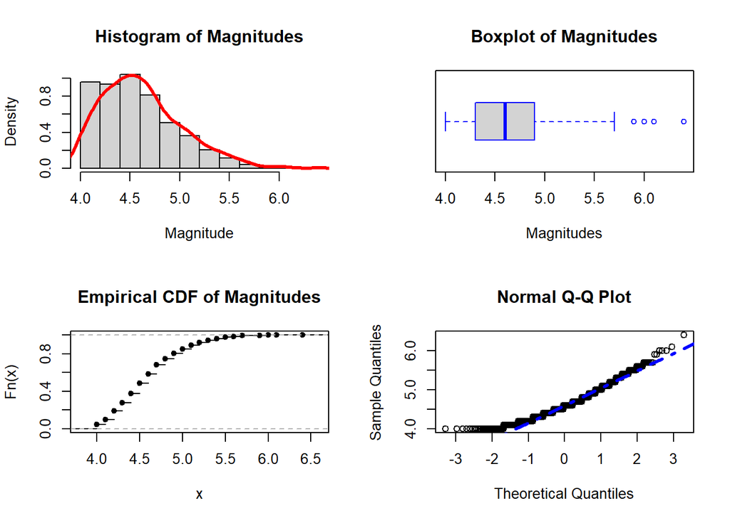

```r
par(mfrow = c(2,2)) # 2 by 2 layout
hist(quakes$mag, freq = F, main = "Histogram of Magnitudes", xlab = "Magnitude") # make a histogram with labels main and xaxis
lines(density(quakes$mag), lwd = 3, col = "red") # plot density curve as red
boxplot(quakes$mag, horizontal = T, at = 0.5, border = "blue", main = "Boxplot of Magnitudes", xlab = "Magnitudes") # make a boxplot in blue
plot(ecdf(quakes$mag), main = "Empirical CDF of Magnitudes") # plot cdf
qqnorm(quakes$mag) # make a qq plot
qqline(quakes$mag, lwd = 3, lty = 4, col = "blue") # make a qq line
```

### (b) [10pt] Outlier detection

There are several outliers labeled by open circles in the boxplot. Write a simple code to print out the indexes of the outliers and then print out the outlier observations.

[**Hint**: you can use the `summary()` function to find out $Q_1$ and $Q_3$.]

**ANSWER**

```r
summary(quakes$mag) # summarize mag
```

```
##    Min. 1st Qu.  Median    Mean 3rd Qu.    Max.
##    4.00    4.30    4.60    4.62    4.90    6.40
```

```r
max_outliers <- quakes$mag[quakes$mag>4.9] # find upper outliears
cat("\nUpper outliers:", max_outliers) # print upper outliers
```

```
##
## Upper outliers: 5.4 6.1 6 5.4 5.2 5.1 5 5 5.5 5.2 5.3 5.2 5.1 5.2 5.2 5.1 5.7 5 5.3 5.1 5 5.1 5 5.3 5.7 6.4 5 5.6 5.3 5.7 5 5.3 5.2 5.2 5.4 5 5 5 5.3 5 5.3 5.1 5.1 5.7 5 5.2 5 5 5 5 5.6 5.1 5.4 5.3 5.2 5.3 5.3 5 5.1 5.4 5 5.5 5 5.1 5.5 5.4 5.1 5.1 5.4 5.1 5.1 5.7 5.1 5.5 5.1 5 5 5.1 5.1 5.3 5 5.7…
```

```r
min_outliers <- quakes$mag[quakes$mag<4.30] # find lower outliers
cat("\nLower outliers:", min_outliers) # print lower outliers
```

```
##
## Lower outliers: 4.2 4.1 4 4 4.2 4 4 4.1 4.2 4 4.2 4 4.1 4.1 4 4.1 4.2 4 4.2 4.2 4.2 4 4.1 4.2 4.2 4 4.2 4.2 4.2 4.2 4.2 4 4.2 4.2 4 4.2 4.2 4.1 4.1 4.1 4.1 4.1 4.2 4.1 4.1 4.2 4 4.2 4.1 4.2 4.2 4.2 4.2 4 4.1 4.2 4.2 4.2 4.2 4.1 4.2 4.2 4 4.2 4 4 4.1 4.1 4.2 4.2 4.1 4.2 4 4.2 4.1 4.2 4 4.2 4.2 4.2…
```

```r
total_outliers <- sum(quakes$mag>4.9) + sum(quakes$mag<4.30) # count toal outliers
cat("\nTotal outliers:", total_outliers) # print total outliers
```

```
##
## Total outliers: 389
```

How many outliers have you found?

### (c) [10pt] Minimum variance unbiased estimates for Normal distribution

Suppose we assume that the earthquake magnitude variable follows a Normal distribution and our 1000 earthquake magnitude observations are independent and identically distributed (iid).

That is, $X_i \sim N(\mu, \sigma^2)$, where $X_i$ is the magnitude of the $i$-th earthquake observation and $i=1,2,\cdots,1000$.

The **minimum variance unbiased estimators (MVUE)** for $\mu$ and $\sigma^2$ are:
$$\widehat{\mu}=\overline{X}=\frac{1}{n}\sum_{i=1}^n X_i \\
\widehat{\sigma^2}=S^2=\frac{1}{n-1}\sum_{i=1}^n (X_i - \overline{X})^2$$

Use existing R functions to calculate the estimates of $\widehat{\mu}$ and $\widehat{\sigma^2}$.

**ANSWER:**

```r
n <- length(quakes$mag) # get length of mag
sum(quakes$mag)/n # find mean
```

```
## [1] 4.6204
```

```r
sum((quakes$mag-mean(quakes$mag))^2)/(n-1) # find sigma
```

```
## [1] 0.1622261
```

Do NOT use any existing R functions, write your own R code to calculate the estimates of $\widehat{\mu}$ and $\widehat{\sigma^2}$.

**ANSWER:**

```r
n <- length(quakes$mag) # save length of mag in n
total_sum <- 0 # initiate sum variable
for ( i in 1:n){ # go from 1 to length of mag
  total_sum <- total_sum+quakes$mag[i] # sum up the value of mag at i
}
mean <- total_sum/n # find mean
mean # print to check
```

```
## [1] 4.6204
```

```r
diff_sum <- 0 # initiate diff sum variable
for ( i in 1:n){ # go from 1 to length of mag
  calc_at_i <- (quakes$mag[i] - mean)^2 # calculate value of difference at i
  diff_sum <- diff_sum + calc_at_i # add calculated value to initiate diff sum value

}
sigma <- diff_sum/(n-1) # culculate sigma
sigma # print to check
```

```
## [1] 0.1622261
```

### (d) [10pt] Visualize your model fitness

To visualize the model fitness, you can add the estimated Normal distribution curve to the histogram plot you have generated in part (a).

Write your own code to generate the following figure.

- make a density histogram first, set `xlim` from 0 to 8.
- plot the empirical density curve in red color on the same figure.
- plot the estimated Normal distribution curve (that is, $X \sim N(\widehat{\mu}, \widehat{\sigma^2})$) as a blue dashed line on the same figure.

**ANSWER**

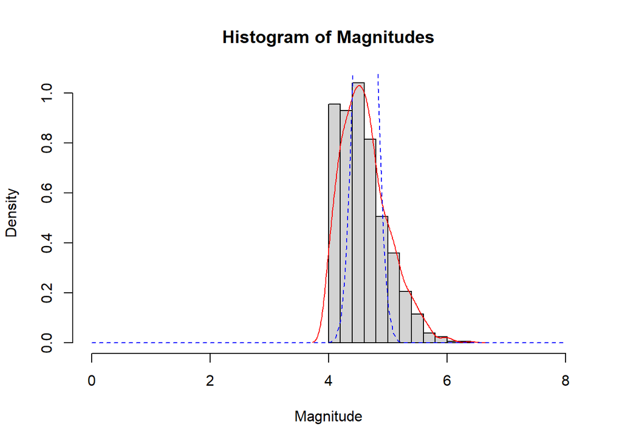

```r
hist(quakes$mag, freq = F, main = "Histogram of Magnitudes", xlab = "Magnitude", xlim = c(0,8)) # label the main graph, x axis and set a limit
lines(density(quakes$mag), col = "red") # plot empirical density curve in red
z <- seq(0,8, length = 100) # create a sequence from 0 to 8 broken into 100
prob_z <- dnorm(z, mean = 4.6204, sd = 0.1622) # get dnorm values for calculated mean and sd
lines(z, prob_z, col = "blue", lty = 2) # plot normal distribution curve as a blue dashed line
```

How does your estimated normal curve differ from the empirical density curve? Do you think the earthquake magnitude observations follow a Normal distribution? Does this result consist with the Q-Q plot you generated in part (a).

### (e) [10pt] Pairwise scatterplots

Run the following code.

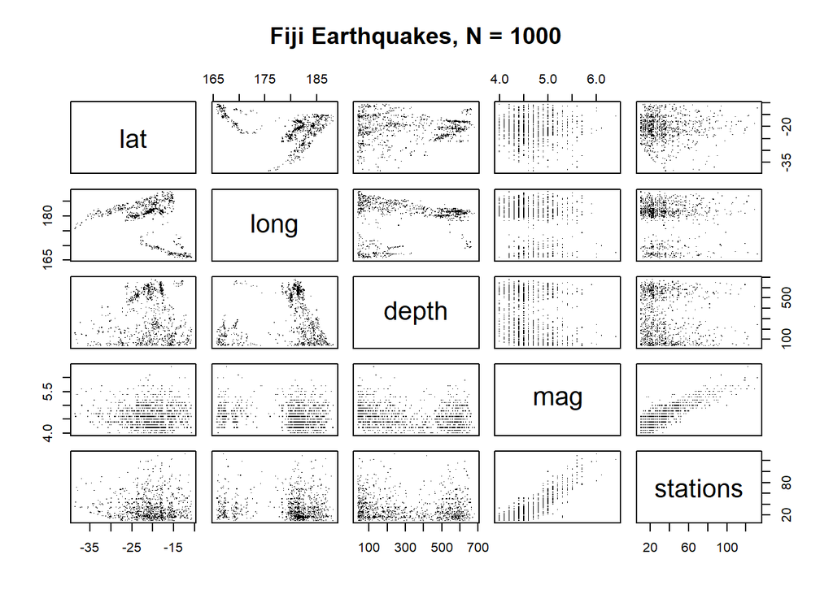

```r
# require(graphics) # load the graphics library

pairs(quakes, main = "Fiji Earthquakes, N = 1000", cex.main=1.2, pch=".")
```

Describe the output figure.

**ANSWER:** The code outputs a 5 by 5 matrix of scatterplots.

Do you think the `mag` variable and `stations` variables are positively correlated? Explain your answer.

**ANSWER:** Yes, they are positively correlated. As the points move across the x axis, the points are higher along the y axis.

### (f) [10pt] Single scatterplot

Write your own R code to reproduce the scatterplot for the `mag` and `stations` variables.

- calculate the covariance and correlation coefficient. [**Hint**: look up the `cor` package.]
- redraw the outlier points you identified in (b) using red color filled diamond symbol.
- add a three-line legend to your plot. The first legend line reports the covariance value; the second legend line reports the correlation coefficient value; and the third legend line indicates the red diamonds are likely outliers.

**ANSWER:**

```r
cor(quakes$mag,quakes$stations) # calculate correlation
```

```
## [1] 0.8511824
```

```r
cov(quakes$mag,quakes$stations) # calculate covariance
```

```
## [1] 7.508181
```

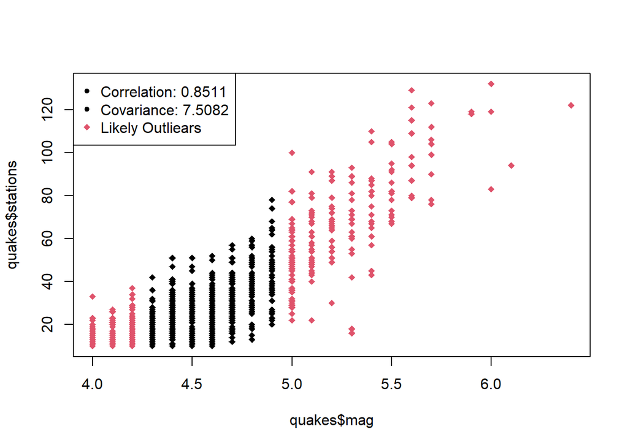

```r
plot(quakes$mag, quakes$stations, pch = 18) # plot all plots
points(quakes$mag[quakes$mag>4.9], quakes$stations[quakes$mag>4.9], col = 2, pch = 18) # plot upper outliers as red diamonds
points(quakes$mag[quakes$mag<4.3], quakes$stations[quakes$mag<4.3], col = 2, pch = 18) # plot lower outliers as red diamonds

legend("topleft", legend = c("Correlation: 0.8511", "Covariance: 7.5082", "Likely Outliears"), col = c(1,1,2), pch = c(20, 20, 18))
```

```r
# legend with three lines correlation,covariance, and likely outliers
```

### (g) [10pt] Earthquake maps

We can plot our earthquake records on a world map using the `maps` package. Look at the following map. Where is Fiji?

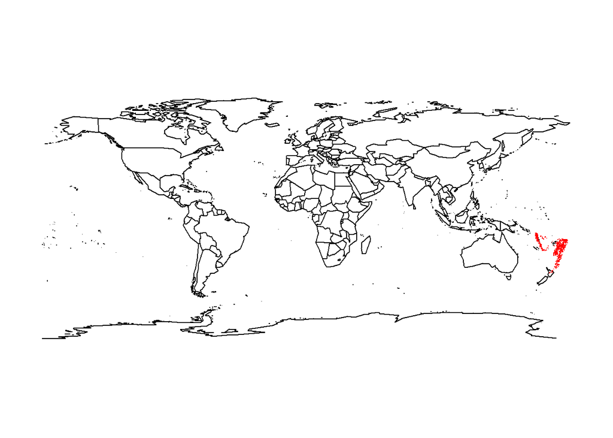

```r
library(maps)
map()
points(quakes$long, quakes$lat, pch=".", col="red")
```

We can also zoom in and make local map of Fiji and its neighborhood area.

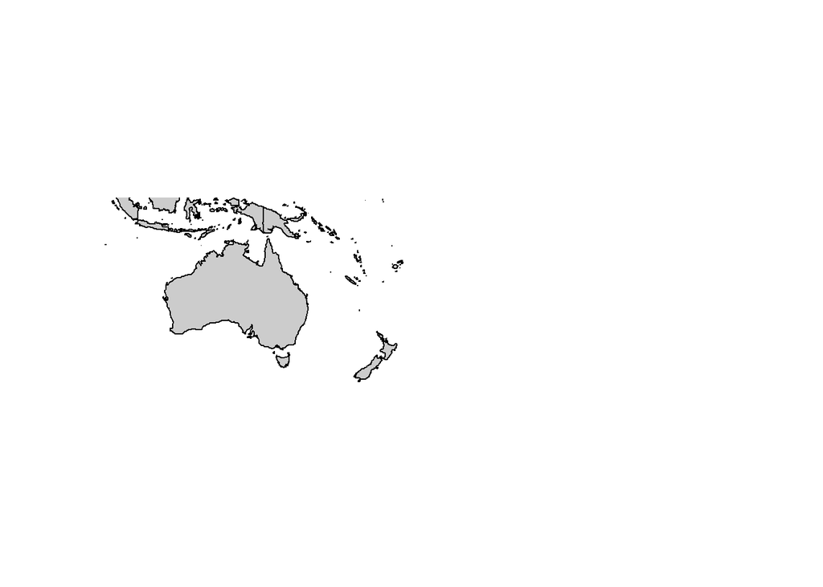

```r
long.mean <- mean(quakes$long)
lat.mean <- mean(quakes$lat)
#orient <- c(lat.mean, long.mean, 0)
xlim <- c(min(quakes$long)/2, max(quakes$long)*1.5)
ylim <- c(min(quakes$lat)-10, max(quakes$lat)+10)
map(database="world", xlim=xlim, ylim=ylim, col="grey80", fill=T)
```

Add our earthquake locations into the above plot as red color dots. Use blue color filled rectangles to mark locations of the outliers identified in part (b).

**ANSWER:**

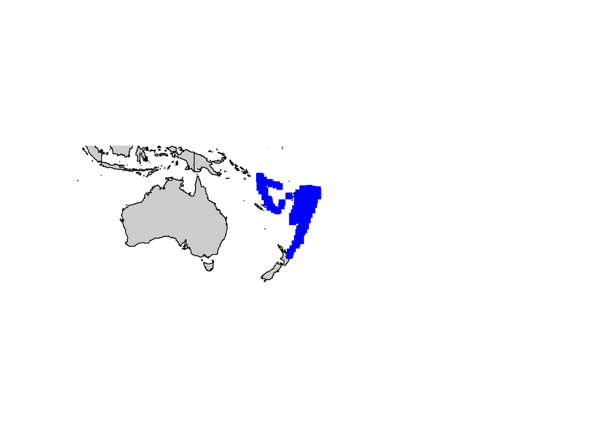

```r
long.mean <- mean(quakes$long)
lat.mean <- mean(quakes$lat)
#orient <- c(lat.mean, long.mean, 0)
xlim <- c(min(quakes$long)/2, max(quakes$long)*1.5)
ylim <- c(min(quakes$lat)-10, max(quakes$lat)+10)
map(database="world", xlim=xlim, ylim=ylim, col="grey80", fill=T)
points(quakes$long, quakes$lat, pch=".", col="red") # plot all points in red
points(quakes$long[quakes$mag>4.9], quakes$lat[quakes$mag>4.9], pch=15, col="blue") # plot all upper outliers as blue rectangle
points(quakes$long[quakes$mag<4.3], quakes$lat[quakes$mag<4.3], pch=15, col="blue") # plot all lower outliers as blue rectangles
```

## **Question 2 [30pt] Introductory Survey**

Take a few minutes to complete the following short survey. *For multiple choice questions, mark appropriate answers using **bold** text*. Note that as long as your complete this survey, you will receive full credit for this question.

### (a) What is your major and concentration (for your degree)?

**ANSWER:** Applied mathematics, general concentration.

### (b) What is your minor (if any)?

**ANSWER:** None.

### (c) Why did you decide to take STAT167?

**ANSWER:** I want to learn more about data science as I plan on Data Science being my career sometime in the future.

### (d) What would you like to get out of this course?

**ANSWER:** I want to learn more about data science applications and machine learning/deep learning.

### (e) What operating system(s) do you run on your primary computer(s)?

[Mark your answer in **bold**].

- **Windows**
- Mac OS X
- Linux
- Other: please specify

### (f) What programming languages do you know?

[Mark all that apply in **bold**].

- BASIC
- C
- **C++**
- C#
- Java
- JavaScript
- **HTML / CSS**
- LISP (lisp, scheme, clojure, etc)
- Perl
- PHP
- **Python**
- Ruby
- SQL
- VB / VBScript
- **R**
- SAS
- **Matlab**
- Julia
- Scala
- Other: please specify

### (g) What is your primary programming language?

**ANSWER:** I use to be proficient in C++ but after not using it for long I’m rusty so I’ll say R.

### (h) How often do you write code (before taking this class)?

[Mark your answer in **bold**].

- daily
- two or more time per week
- **once per week**
- less than once per week
- little to no programming experience

### (i) Overall, how comfortable are you with programming?

[Mark your answer in **bold**].

- 1 (less comfortable)
- 2
- 3
- **4**
- 5 (very comfortable)

### (j) What probability and statistics courses have you already taken, if any?

**ANSWER:** Stats 100AB, Stat 147

###(k) What computer science courses have you already taken, if any?

**Answer:** Cs10, Cs12